# **Xiaoping’s CV**

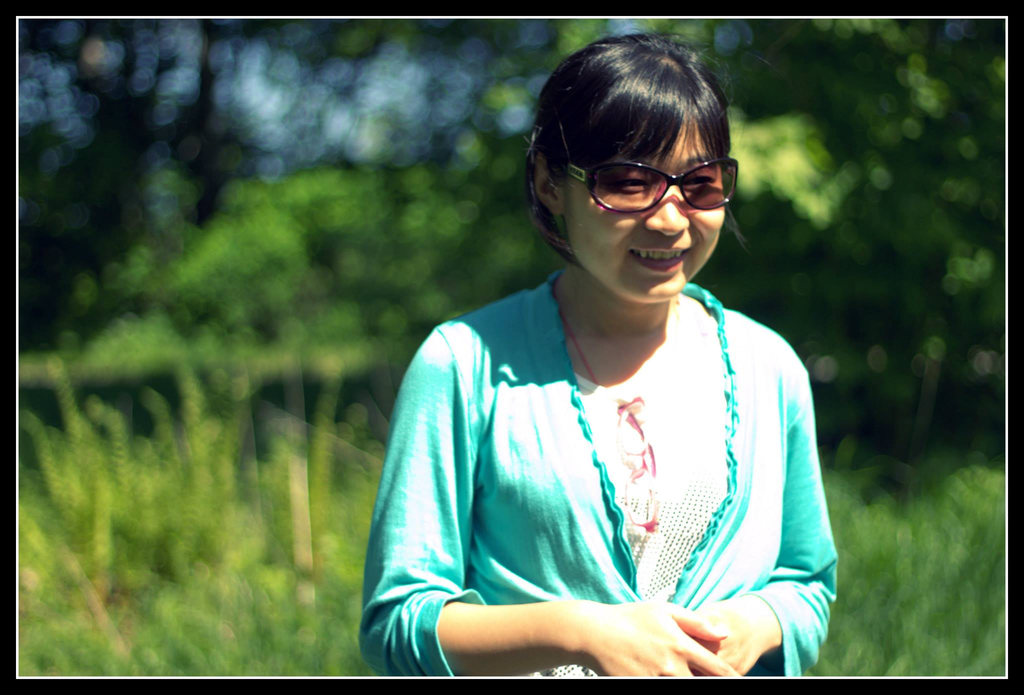

# **PROFILE**

I am now mainly contributing to research on

- Genome wide association studies focus on pregnancy-related outcomes (placenta weight, birth weight and gestational duration) and selected childhood diseases (febrile seizure, psychiatric disease, epilepsy, metabolic disease, and congenital heart defect)
- Polygenic risk score estimation
- Linear regression and Logistic regression analysis
- Mendelian randomization analysis for Birth weight and psychiatric disease
- Integrate Single-cell RNA sequencing data with genome-wide association results to distinguishes disease association cells

PhD and 5 years postdoc experience in **Quantitative Genetics and Genomics**. I was mainly contributing to research focusing on

- Quantitative genetics and genomics
- Population genetics
- Statistical genetics

My Publications

I can offer

- Years of experience in both **human genetics** and **animal breeding and genetics**
- Years of experience on bioinformatics and post-GWAS analysis
- Years of experience research within the field of genome wide association analysis and genomic prediction
- Knowledge about different statistical genetic models - linear mixed model, Bayesian model and logistic regression model.
- Experience in handling large data set, such as whole genome sequence data and different density of SNP-chip data
- Rich experience with linux, R, and python
- Rich experience in reproducible research using Snakemake and conda

I thrive in diverse, team-based environments, and comfortable with leading and being led.